# 红酒数据集探索性数据分析

## 柠檬酸和酸类在不同质量下的相关关系:

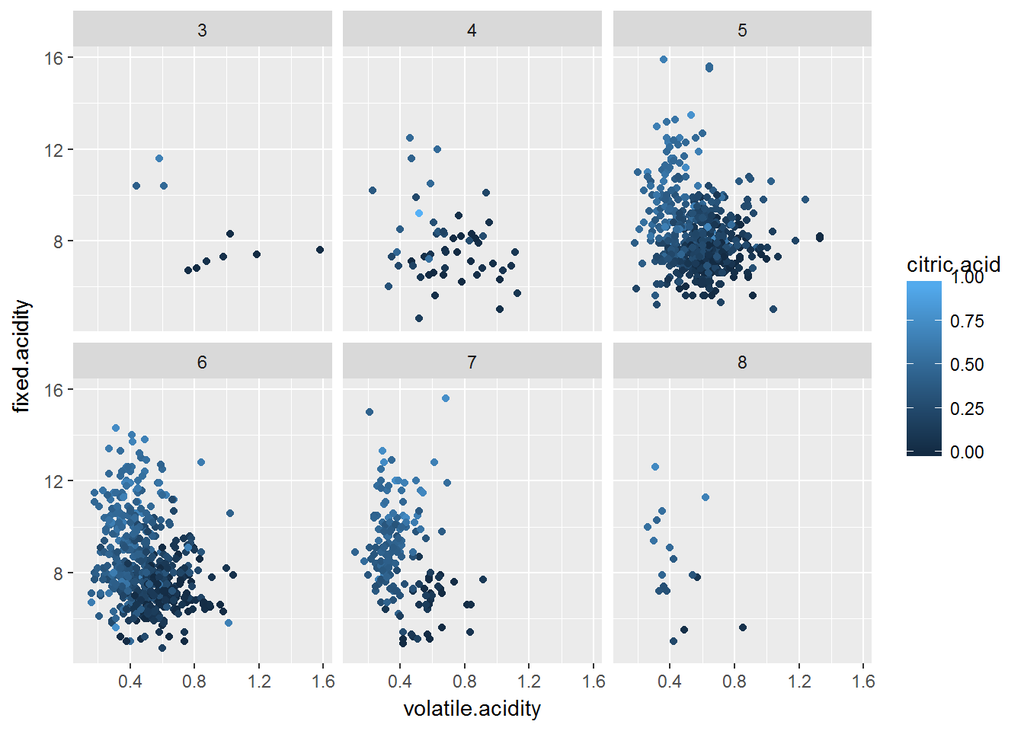

高柠檬酸总出现在挥发酸少的区域,并倾向于出现在高固定酸区域。再一次确认了质量越高的红酒，其挥发酸含量越少。

## 总二氧化硫,游离二氧化硫和硫化物在不同质量下的相关关系:

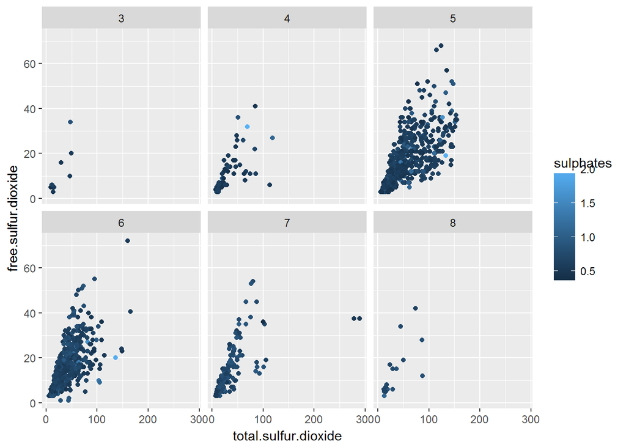

总二氧化硫和游离二氧化硫正相关。

## 密度酒精和残糖在不同质量下的相关关系:

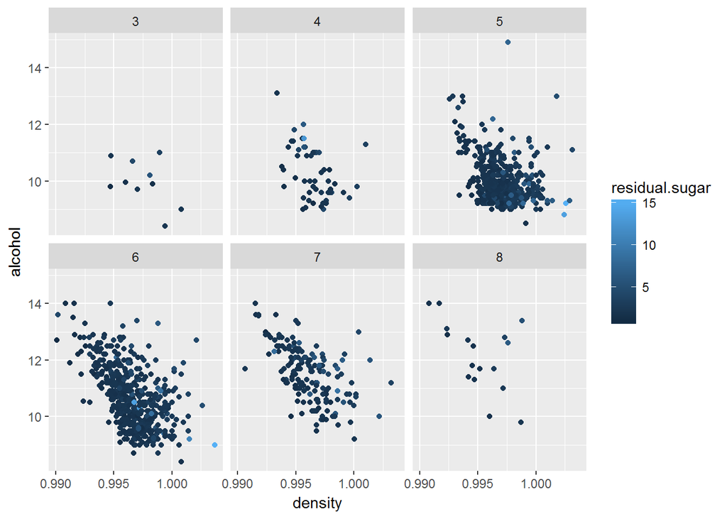

高质量酒出现在酒精度高区域,高残糖出现在高密度区域。

## 酒精和密度在不同质量下的相关关系:

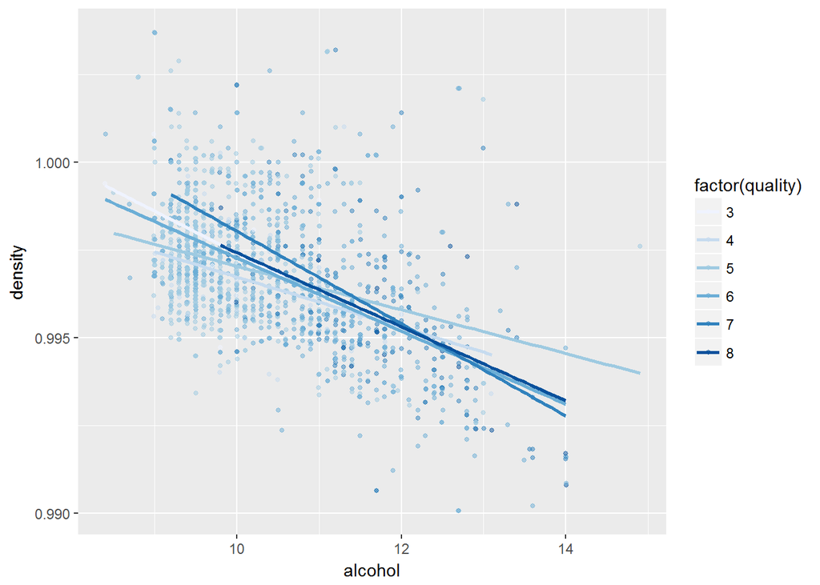

不同质量的红酒,都是酒精和密度呈负相关。

# 多变量分析

### 探讨你在这部分探究中观察到的一些关系。通过观察感兴趣的特性，是否存在相互促进的特性？

质量较好的红酒主要分布在挥发性酸较低和固定酸较高的区域，而质量较差的红酒则更多集中在固定酸较低和挥发性酸较高的区域。 总二氧化硫和游离二氧化硫正相关。 高质量酒出现在酒精度高区域,高残糖出现在高密度区域。 不同质量的红酒,都是酒精和密度呈负相关。

猜测柠檬酸和固定酸有促进作用,总二氧化硫和游离二氧化硫有促进作用。 猜测高残糖和低酒精浓度对高密度有促进作用。

### 这些特性之间是否存在有趣或惊人的联系呢？

没有挥发酸和固定酸同时特别高的红酒,也许二者可以单向转化。 密度也许由残糖和酒精浓度决定。

### 选项：你是否创建过数据集的任何模型？讨论你模型的优缺点。

# 定稿图与总结

### 绘图一

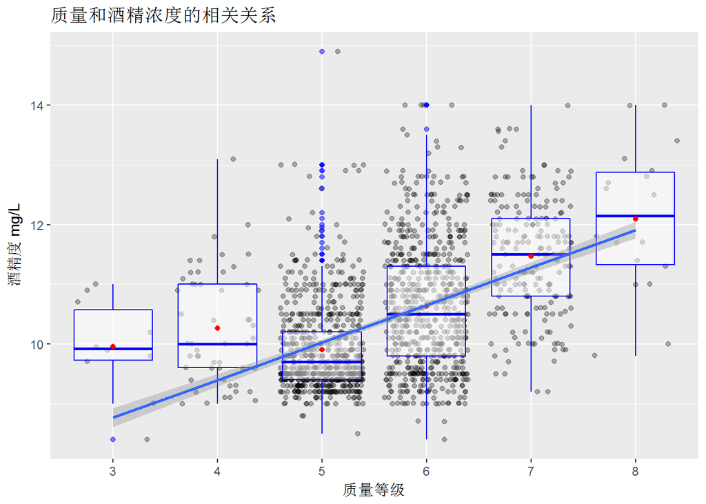

### 描述一

酒精浓度越高往往对红酒质量越高。

### 绘图二

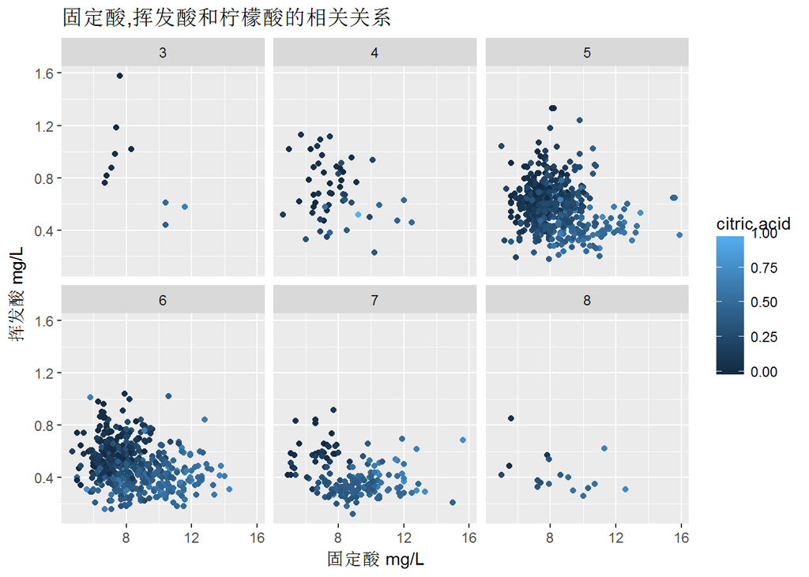

### 描述二

高柠檬酸总出现在挥发酸少的区域,并倾向于出现在高固定酸区域。

### 绘图三

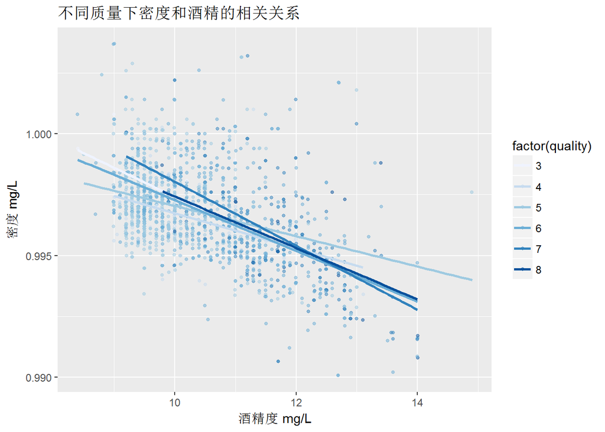

### 描述三

不同质量的红酒,都是酒精和密度呈负相关。

# 反思

利用这些数据将来还可以做进一步分析，例如用机器学习的算法构建一个合理的红酒质量的预测模型，输入密度、酒精浓度等变量，得到红酒质量的预测结果。

# reference

- https://s3.amazonaws.com/content.udacity-data.com/courses/ud651/diamondsExample_2016-05.html
- https://github.com/richard-renxin/P6_redwine
- https://github.com/esskeetit0817/EDA-projcet
- https://github.com/jtsou/Red-Wine-Analysis-with-R